# Homework #5 for AN597

Julie Jung

November 8, 2017

# Bootstrapping Standard Errors and CIs for Linear Models.

When we initially discussed the central limit theorem and confidence intervals, we showed how we could use bootstrapping to estimate standard errors and confidence intervals around certain parameter values, like the mean. Using bootstrapping, we could also do the same for estimating standard errors and CIs around regression parameters, such as β coefficients.

**[1] Using the “KamilarAndCooperData.csv” dataset, run a linear regression looking at log(HomeRange_km2) in relation to log(Body_mass_female_mean) and report your β coeffiecients (slope and intercept).**

```r
# import data

library(curl)
f <- curl("https://raw.githubusercontent.com/fuzzyatelin/fuzzyatelin.github.io/master/AN597_Fall17/KamilarAndCooperData.csv")
d <- read.csv(f, header = TRUE, sep = ",", stringsAsFactors = FALSE)
head(d)
```

```
##               Scientific_Name          Family          Genus      Species
## 1 Allenopithecus_nigroviridis Cercopithecidae Allenopithecus nigroviridis
## 2         Allocebus_trichotis Cercopithecidae      Allocebus    trichotis
## 3           Alouatta_belzebul        Atelidae       Alouatta     belzebul
## 4             Alouatta_caraya        Atelidae       Alouatta       caraya
## 5            Alouatta_guariba        Atelidae       Alouatta      guariba
## 6           Alouatta_palliata        Atelidae       Alouatta     palliata
##   Brain_Size_Species_Mean Brain_Size_Female_Mean   Brain_size_Ref
## 1                   58.02                  53.70 Isler et al 2008
## 2                      NA                     NA
## 3                   52.84                  51.19 Isler et al 2008
## 4                   52.63                  47.80 Isler et al 2008
## 5                   51.70                  49.08 Isler et al 2008
## 6                   49.88                  48.04 Isler et al 2008
##   Body_mass_male_mean Body_mass_female_mean Mass_Dimorphism
```

[output cut: 69 more lines]

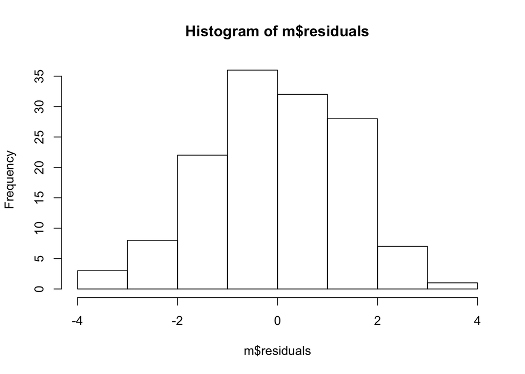

```r
# run a linear regression looking at log(HomeRange_km2) in relation to log(Body_mass_female_mean)

# check for normality
m <- lm(data = d, log(HomeRange_km2) ~ log(Body_mass_female_mean))
hist(m$residuals)
library(car)
```

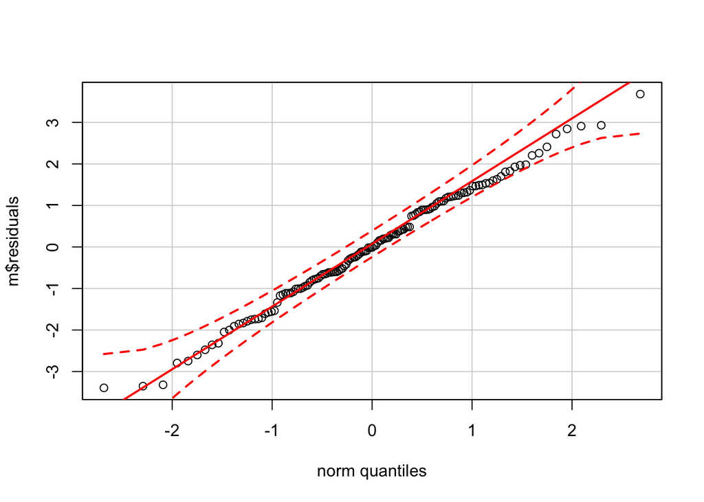

```r
qqPlot(m$residuals)
```

```r
s <- shapiro.test(m$residuals)
s  #normal
```

```
##
##  Shapiro-Wilk normality test
##
## data:  m$residuals
## W = 0.9939, p-value = 0.8258
```

```r
# report your β coeffiecients (slope and intercept).
t <- coef(summary(m))
t <- data.frame(unlist(t))
colnames(t) <- c("Est", "SE", "t", "p")
t
```

```
##                                  Est         SE         t            p
## (Intercept)                -9.441231 0.67293459 -14.02994 3.820677e-28
## log(Body_mass_female_mean)  1.036432 0.08487709  12.21097 1.447292e-23
```

```r
beta0 <- t$Est[1] #The intercept, β0, is the PREDICTED value of y when the value of x is zero.
beta1 <- t$Est[2] #The slope, β1 is EXPECTED CHANGE in units of y for every 1 unit of change in x

beta0
```

```
## [1] -9.441231
```

```r
beta1
```

```
## [1] 1.036432
```

> beta0 [1] -9.441231 beta1 [1] 1.036432

The intercept, β0, is -9.441231 - this is the PREDICTED value of y when the value of x is zero. The slope, β1, is 1.036432 - this is EXPECTED CHANGE in units of y for every 1 unit of change in x.

### Plot

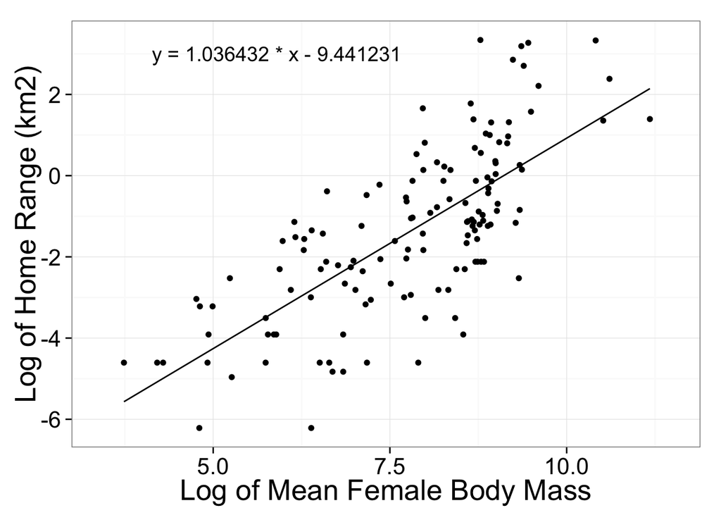

```r
library(ggplot2)
ggplot(data = d, aes(x = log(Body_mass_female_mean), y = log(HomeRange_km2))) +
  geom_point()+
  geom_smooth(method="lm", se=F, color="black")+
  annotate("text", x = 5.9, y = 3, label = "y = 1.036432 * x - 9.441231")+
  ylab("Log of Home Range (km2)")+
  theme_bw(20) +
  xlab("Log of Mean Female Body Mass")
```

**[2] Then, use bootstrapping to sample from your data 1000 times with replacement, each time fitting the same model and calculating the same coefficients. This generates a sampling distribution for each β coefficient.**

## Use Boot to do this:

```r
library(boot)
#function to obtain regression weights
bs <- function(formula, data=d, indices) {
  d<-data[indices, ] #allows boot to select sample
  fit<-lm(formula, data=d)
  return(coef(fit))
}

results <- boot(data=d, statistic=bs, R=1000, formula=log(HomeRange_km2)~log(Body_mass_female_mean))

# view results
results
```

```
##
## ORDINARY NONPARAMETRIC BOOTSTRAP
##
##
## Call:
## boot(data = d, statistic = bs, R = 1000, formula = log(HomeRange_km2) ~
##     log(Body_mass_female_mean))
##
##
## Bootstrap Statistics :
##      original       bias    std. error
## t1* -9.441231 -0.031923087  0.61904050
## t2*  1.036432  0.004304937  0.07906375
```

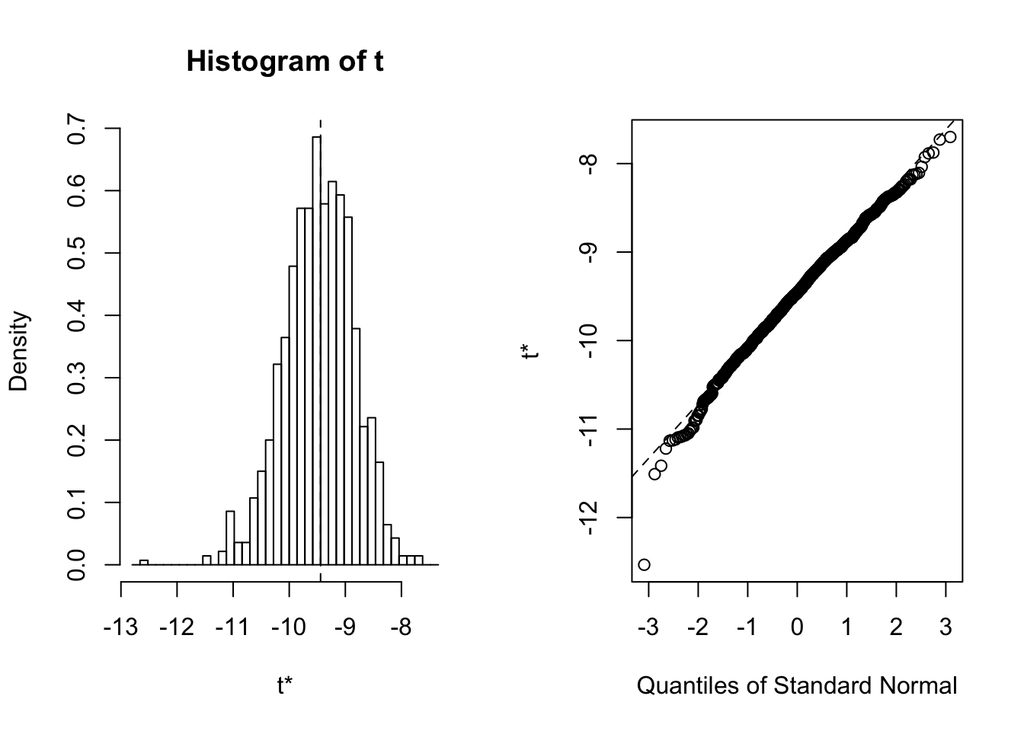

```r
plot(results, index=1) # intercept
```

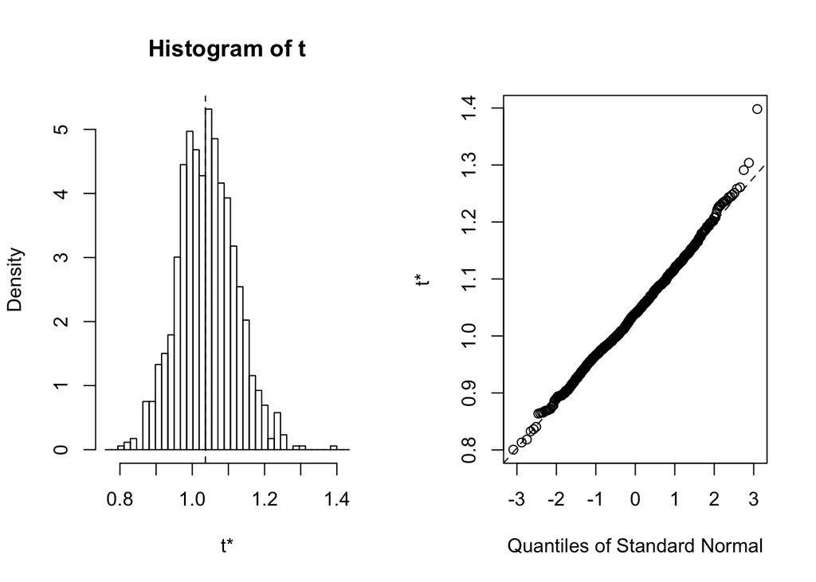

```r
plot(results, index=2) # wt
```

```r
# get 95% confidence intervals
boot.ci(results, type="bca", index=1) # intercept
```

```
## BOOTSTRAP CONFIDENCE INTERVAL CALCULATIONS
## Based on 1000 bootstrap replicates
##
## CALL :
## boot.ci(boot.out = results, type = "bca", index = 1)
##
## Intervals :
## Level       BCa
## 95%   (-10.760,  -8.328 )
## Calculations and Intervals on Original Scale
```

```r
boot.ci(results, type="bca", index=2) # wt
```

```
## BOOTSTRAP CONFIDENCE INTERVAL CALCULATIONS
## Based on 1000 bootstrap replicates
##
## CALL :
## boot.ci(boot.out = results, type = "bca", index = 2)
##
## Intervals :
## Level       BCa
## 95%   ( 0.888,  1.198 )
## Calculations and Intervals on Original Scale
```

### compare SEs and CIs

**How does the former compare to the SE estimated from your entire dataset using the formula for standard error implemented in lm()?**

```r
X<- summary(m)$coef
X[,2]
```

```
##                (Intercept) log(Body_mass_female_mean)
##                 0.67293459                 0.08487709
```

ENTIRE DATASET RESULTS: (Intercept) log(Body_mass_female_mean) 0.67293459 0.08487709

THESE ARE REALLY SIMILAR.

**How does the latter compare to the 95% CI estimated from your entire dataset?**

```r
confint(m)
```

```
##                                  2.5 %    97.5 %
## (Intercept)                -10.7720889 -8.110374
## log(Body_mass_female_mean)   0.8685707  1.204292
```

ENTIRE DATASET RESULTS: 2.5 % 97.5 % (Intercept) -10.7720889 -8.110374 log(Body_mass_female_mean) 0.8685707 1.204292

ALSO REALLY SIMILAR.

## HERE I ATTEMPT TO DO IT MANUALLY WITHOUT USING THE BOOT PACKAGE:

```r
set.beta0<-NULL # sets up a dummy variable to hold our 1000 simulations
set.beta1<-NULL

for (i in 1:1000) {
  m <- lm(data=d, log(HomeRange_km2) ~ log(Body_mass_female_mean))
  summary(m)
  t <- coef(summary(m))
  t <- data.frame(unlist(t))
  colnames(t) <- c("Est", "SE", "t", "p")
  t

  beta0 <- t$Est[1] #The intercept, β0, is the PREDICTED value of y when the value of x is zero.
  beta1 <- t$Est[2] #The slope, β1 is EXPECTED CHANGE in units of y for every 1 unit of change in x

  set.beta0[i] <- mean(sample(beta0, 1000, replace=TRUE))
  set.beta1[i] <- mean(sample(beta1, 1000, replace=TRUE))
  }
```

Plot

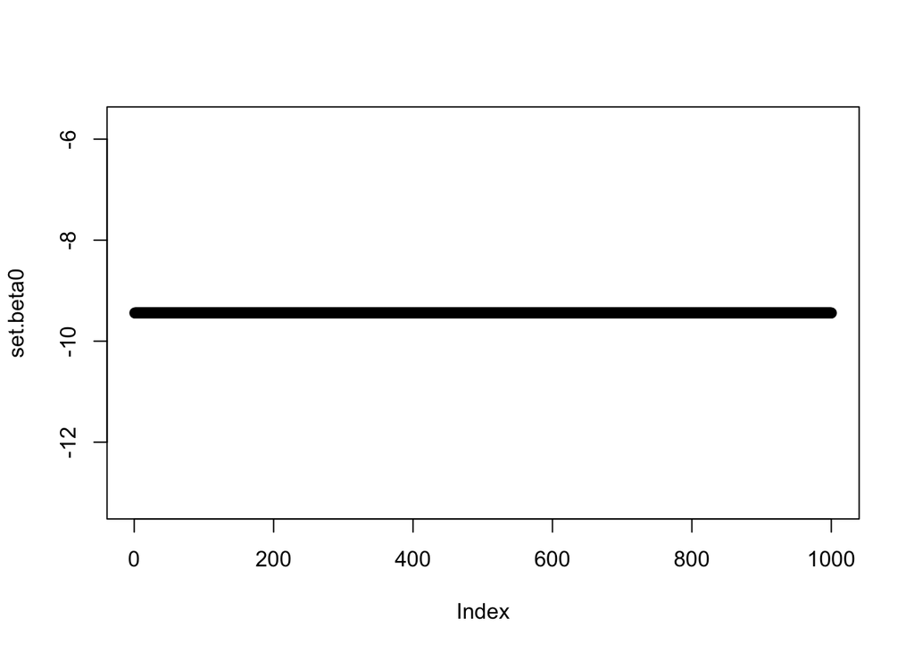

```r
plot(set.beta0)
```

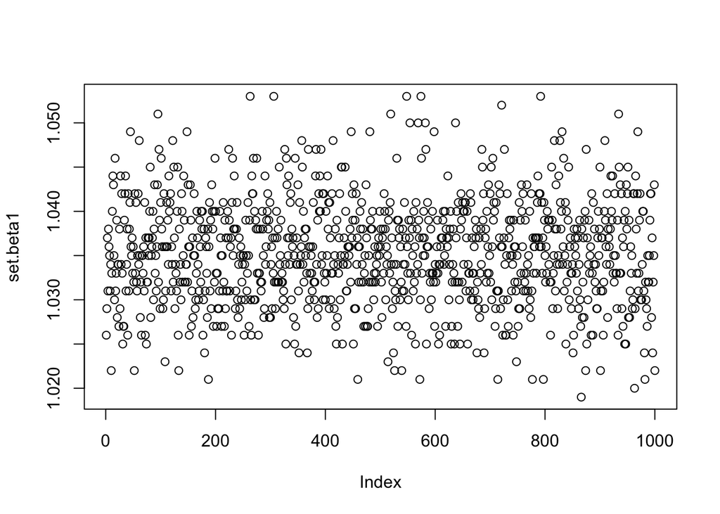

```r
plot(set.beta1)
```

It’s weird that I’m getting -9.441231 every time for beta 0, which is why I went back and added code to do it the easier way (using boot) as well at the beginning of this script/notebook.

**Estimate the standard error for each of your β coefficients as the standard deviation of the sampling distribution from your bootstrap and determine the 95% CI for each of your β coefficients based on the appropriate quantiles from your sampling distribution.**

## Standard error estimation

```r
#Estimate the standard error for each of your β coefficients as the standard deviation of the sampling distribution from your bootstrap

t$SE[1]
```

```
## [1] 0.6729346
```

```r
t$SE[2]
```

```
## [1] 0.08487709
```

```r
# an alternative way, if you want to get it manually:
SE <- function(x) {
    sd(x)/sqrt(length(x))
}

SE(set.beta0)
```

```
## [1] 0
```

```r
SE(set.beta1)
```

```
## [1] 0.0001876185
```

The SE of the intercept, β0, is 0.6729346. The SE of the slope, β1, is 0.08487709.

```r
# determine the 95% CI for each of your β coefficients based on the appropriate quantiles from your sampling distribution.

quantile(set.beta0, c(0.025, 0.975))
```

```
##      2.5%     97.5%
## -9.441231 -9.441231
```

```r
quantile(set.beta1, c(0.025, 0.975))
```

```
##  2.5% 97.5%
## 1.024 1.048
```

**How does the former compare to the SE estimated from your entire dataset using the formula for standard error implemented in lm()?**

The former (bootstrap SE) is much smaller than the SE estimated from my entire dataset. (code below)

```r
#SE estimated from your entire dataset using the formula for standard error implemented in lm()

X<- summary(m)$coef
X[,2]
```

```
##                (Intercept) log(Body_mass_female_mean)
##                 0.67293459                 0.08487709
```

**How does the latter compare to the 95% CI estimated from your entire dataset?**

The latter (bootstrap CIs) are much tighter/smaller/more precise than the CIs estimated from my entire dataset. (code below)

```r
confint(m)
```

```
##                                  2.5 %    97.5 %
## (Intercept)                -10.7720889 -8.110374
## log(Body_mass_female_mean)   0.8685707  1.204292
```

## **EXTRA CREDIT: + 2: Write a FUNCTION that takes as its arguments a dataframe, “d”, a linear model, “m” (as a character string, e.g., “logHR~logBM”), a user-defined confidence interval level, “conf.level” (with default = 0.95), and a number of bootstrap replicates, “n” (with default = 1000). Your function should return a dataframe that includes: beta coefficient names; beta coefficients, standard errors, and upper and lower CI limits for the linear model based on your entire dataset; and mean beta coefficient estimates, SEs, and CI limits for those coefficients based on your bootstrap.**

### NOTE: I did this using the part of my code that doesn’t use Boot, which I didn’t get to come out quite right… but the function still works :)

```r
boots <- function(d, m, conf.level=0.95, n=1000) {

  # d == dataframe
  # m == a linear model as a character string
  # conf.level == user-defined confidence interval level, default 0.95
  # n == number of bootstrap replicates


  # beta coefficient names
  betanames <- c("beta0", "beta1")

  # beta coefficients
  m <- lm(data=d, m)
  t <- coef(summary(m))
  t <- data.frame(unlist(t))
  colnames(t) <- c("Est", "SE", "t", "p")
  t
  beta0 <- t$Est[1] #The intercept, β0, is the PREDICTED value of y when the value of x is zero.
  beta1 <- t$Est[2] #The slope, β1 is EXPECTED CHANGE in units of y for every 1 unit of change in x

  betacoefs <- c(beta0, beta1)

  # standard errors
  X<- summary(m)$coef
  SE.entire<-X[,2]

  # upper and lower CI limits for the linear model based on your entire dataset
  lower.CI.entire<-confint(m)[,1]
  upper.CI.entire<-confint(m)[,2]

  #bootstrap analysis

  set.beta0<-NULL # sets up a dummy variable to hold our 1000 simulations
  set.beta1<-NULL

  for (i in 1:1000) {
    m <- lm(data=d, m)
    t <- coef(summary(m))
    t <- data.frame(unlist(t))
    colnames(t) <- c("Est", "SE", "t", "p")
    t
    beta0 <- t$Est[1] #The intercept, β0, is the PREDICTED value of y when the value of x is zero.
    beta1 <- t$Est[2] #The slope, β1 is EXPECTED CHANGE in units of y for every 1 unit of change in x
    set.beta0[i] <- mean(sample(beta0, 1000, replace=TRUE))
    set.beta1[i] <- mean(sample(beta1, 1000, replace=TRUE))
  }

  # mean beta coefficient estimates for those coefficients based on your bootstrap
  mean.beta0.bootstrap <- mean(set.beta0)
  mean.beta1.bootstrap <- mean(set.beta1)
  mean.bootstrap <- c(mean.beta0.bootstrap, mean.beta1.bootstrap)

  # SEs for those coefficients based on your bootstrap
  SE <- function(x) {
      sd(x)/sqrt(length(x))
  }

  SE.beta0.bootstrap <- SE(set.beta0)
  SE.beta1.bootstrap <- SE(set.beta1)
  SE.bootstrap <- c(SE.beta0.bootstrap, SE.beta1.bootstrap)

  # CI limits for those coefficients based on your bootstrap

  CI.beta0.bootstrap <- quantile(set.beta0, c(0.025, 0.975))
  CI.beta1.bootstrap <- quantile(set.beta1, c(0.025, 0.975))

  CI.lower.bootstrap <- c(CI.beta0.bootstrap[1], CI.beta1.bootstrap[1])
  CI.upper.bootstrap <- c(CI.beta0.bootstrap[2], CI.beta1.bootstrap[2])

  #print result
  df <- data.frame(betanames, betacoefs, SE.entire, lower.CI.entire, upper.CI.entire, mean.bootstrap, SE.bootstrap, CI.lower.bootstrap, CI.upper.bootstrap)

  return (df)
}

boots(d=d, m= log(HomeRange_km2) ~ log(Body_mass_female_mean))
```

```
##                            betanames betacoefs  SE.entire lower.CI.entire
## (Intercept)                    beta0 -9.441231 0.67293459     -10.7720889
## log(Body_mass_female_mean)     beta1  1.036432 0.08487709       0.8685707
##                            upper.CI.entire mean.bootstrap SE.bootstrap
## (Intercept)                      -8.110374      -9.441231   0.00000000
## log(Body_mass_female_mean)        1.204292       1.035059   0.00018813
##                            CI.lower.bootstrap CI.upper.bootstrap
## (Intercept)                         -9.441231          -9.441231
## log(Body_mass_female_mean)           1.024000           1.047000
```

**EXTRA EXTRA CREDIT: + 1: Graph each beta value from the linear model and its corresponding mean value, lower CI and upper CI from a bootstrap as a function of number of bootstraps from 10 to 200 by 10s. HINT: the beta value from the linear model will be the same for all bootstraps and the mean beta value may not differ that much!**

```r
### i haven't gotten this part to work yet!

# set.beta0<-NULL # sets up a dummy variable to hold our 1000 simulations
# set.beta1<-NULL
#
# for (i in 200) {
#   t <- coef(summary(m))
#   t <- data.frame(unlist(t))
#   colnames(t) <- c("Est", "SE", "t", "p")
#   t
#   beta0 <- t$Est[1] #The intercept, β0, is the PREDICTED value of y when the value of x is zero.
#   beta1 <- t$Est[2] #The slope, β1 is EXPECTED CHANGE in units of y for every 1 unit of change in x
#   set.beta0[i] <- mean(sample(beta0, 200, replace=TRUE))
#   set.beta1[i] <- mean(sample(beta1, 200, replace=TRUE))
#
#   plot(x = i, y = set.beta0)
#
#   plot(x,y1,type="l",col="red")
#   lines(x,y2,col="green")
# }
#
# plot(x = seq(1:length(set.beta0)), y = set.beta0)
```